# Numpy_Pandas_Matplotlib

## NumPy

The purpose of this tutorial is to familiarize with NumPy array creation, its operations like slicing, indexing, transposing and some important mathematical functions. ❖ NumPy is an N-dimensional array type called ndarray. ❖ It describes the collection of items of the same type. Each element in ndarray is an object of data-type object (called dtype) ❖ Images are loaded into NumPy array

**1. Create a 1-D NumPy array ‘A’, from list [5 8 10 5 4 3 2 1], check its parameters (ndim, shape, itemsize, dtype)**

```python
import numpy as np
A=np.array([5, 8, 10, 5, 4, 3, 2, 1], dtype=int)
print('ndim = {}, shape = {}, itemsize = {}, dtype = {}'.format(A.ndim, A.shape, A.itemsize, A.dtype))
#Item size is in bytes
```

```
ndim = 1, shape = (8,), itemsize = 8, dtype = int64
```

**2. Create a 2-D NumPy array ‘B’. Check its parameters B = [[ True False] [False True]]**

```python
B=np.array([[True,False],[False,True]], dtype=bool)
print('ndim = {}, shape = {}, itemsize = {}, dtype = {}'.format(B.ndim, B.shape, B.itemsize, B.dtype))
```

```
ndim = 2, shape = (2, 2), itemsize = 1, dtype = bool
```

```python
C=np.ones((1,4))
print(C)
```

```
[[1. 1. 1. 1.]]
```

4. Create a 2-D NumPy array,‘D’ of size 5 * 4, consisting of number from  
0,1,2,3,4….20

```
 D =
        [[ 0  1  2  3]
         [ 4  5  6  7]
         [ 8  9 10 11]
         [12 13 14 15]
         [16 17 18 19]]
```

```python
D=np.arange(20).reshape(5, 4)
print(D)
```

```
[[ 0  1  2  3]
 [ 4  5  6  7]
 [ 8  9 10 11]
 [12 13 14 15]
 [16 17 18 19]]
```

**5. Add array ‘C’ to array ‘D’. (You will be doing broadcasting!!)**

```python
print(C + D)
```

```
[[ 1.  2.  3.  4.]
 [ 5.  6.  7.  8.]
 [ 9. 10. 11. 12.]
 [13. 14. 15. 16.]
 [17. 18. 19. 20.]]
```

**6. Transpose the 2-D array ‘D’**

```python
print(D.T)
```

```
[[ 0  4  8 12 16]
 [ 1  5  9 13 17]
 [ 2  6 10 14 18]
 [ 3  7 11 15 19]]
```

**7. From array ‘D’ use NumPy 2-D slicing to extract below slice [[ 0 2 4] [10 12 14]]**

```python
D=np.arange(20).reshape(4,5)
print(D)
print("\nAfter slicing operator\n")
print(D[0:4:2, 0:5:2])
```

```
[[ 0  1  2  3  4]
 [ 5  6  7  8  9]
 [10 11 12 13 14]
 [15 16 17 18 19]]

After slicing operator

[[ 0  2  4]
 [10 12 14]]
```

**8. From array ‘D’ extract the corner elements using NumPy Indexing [[ 0 4] [15 19]]**

```python
rows = np.array([[0,0],[3,3]])
cols = np.array([[0,4],[0,4]])

print('\nThe corner elements of this array are:    \n', D[rows,cols])
```

```
The corner elements of this array are:
 [[ 0  4]
 [15 19]]
```

**9. Modify the ‘D’ array to make center elements 0 i.e.**

D =

```
      [[ 0  1  2  3  4]
       [ 5  0  0  0  9]
       [10  0  0  0  14]
       [15 16 17 18 19]]
```

```python
D[1:3, 1:4] = 0
print('Modified D = \n', D)
```

```
Modified D =
 [[ 0  1  2  3  4]
 [ 5  0  0  0  9]
 [10  0  0  0 14]
 [15 16 17 18 19]]
```

```python
E=np.random.randint(1,30, 20).reshape(4,5)
print("\n Matrix E = \n", E)
print("\nMaximum of all columns = \n", np.amax(E, 0))
print("\nMean of all numbers = ", np.mean(E))
print("\nSTD of all numbers = ", np.std(E))
```

```
 Matrix E =
 [[ 7  2 15  9 27]
 [29  3  8 21 20]
 [14 21  4 27  8]
 [ 9 22 24 11 28]]

Maximum of all columns =
 [29 22 24 27 28]

Mean of all numbers =  15.45

STD of all numbers =  8.83444961500149
```

```
Type of image =  <class 'numpy.ndarray'>
Size of image =  (401, 649, 4)
```

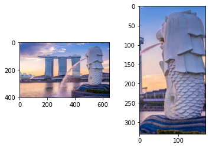

```python
import numpy as np
import cv2
from matplotlib import pyplot as plt
import matplotlib.image as mpimg

img = mpimg.imread('Sample.PNG')

print("Type of image = ", type(img))
print("Size of image = ", img.shape)

plt.subplot(1,2,1)
plt.imshow(img)


plt.subplot(1,2,2)
plt.imshow(img[20:350, 430:600])
```

### Any operation you can do with numpy array can be done on img object

## Pandas

```python
import pandas as pd

year = pd.Series([2017, 2018, 800])
revenue = pd.Series([1000, 1200, 1500])
expense = pd.Series([800, 900, 1100])

table_account = pd.DataFrame({'year':year, 'revenue':revenue, 'expense':expense})

print (table_account)
```

```
   year  revenue  expense
0  2017     1000      800
1  2018     1200      900
2   800     1500     1100
```

```python
table_account['savings'] = table_account['revenue'] - table_account['expense']
table_account['persons'] = ['abc', 'def', 'ghi']

print("\nNew modified data table:\n", table_account)
```

```
New modified data table:
    year  revenue  expense  savings persons
0  2017     1000      800      200     abc
1  2018     1200      900      300     def
2   800     1500     1100      400     ghi
```

**3.Load a CSV file (tips.csv provided) to load a CSV file into a pandas dataframe. Now display .head() of dataframe. Then display .description() of dataframe. Name this dataframe as ‘tips_table’. Sample .head() of tips table.**

```python
tips_table=pd.read_csv('tips.csv')
tips_table.head()
```

|  | total_bill | tip | sex | smoker | day | time | size |
| --- | --- | --- | --- | --- | --- | --- | --- |
| 0 | 16.99 | 1.01 | Female | No | Sun | Dinner | 2 |
| 1 | 10.34 | 1.66 | Male | No | Sun | Dinner | 3 |
| 2 | 21.01 | 3.50 | Male | No | Sun | Dinner | 3 |
| 3 | 23.68 | 3.31 | Male | No | Sun | Dinner | 2 |
| 4 | 24.59 | 3.61 | Female | No | Sun | Dinner | 4 |

```python
tips_table.describe()
```

|  | total_bill | tip | size |
| --- | --- | --- | --- |
| count | 244.000000 | 244.000000 | 244.000000 |
| mean | 19.785943 | 2.998279 | 2.569672 |
| std | 8.902412 | 1.383638 | 0.951100 |
| min | 3.070000 | 1.000000 | 1.000000 |
| 25% | 13.347500 | 2.000000 | 2.000000 |
| 50% | 17.795000 | 2.900000 | 2.000000 |
| 75% | 24.127500 | 3.562500 | 3.000000 |
| max | 50.810000 | 10.000000 | 6.000000 |

## MATPLOTLIB and SEABORN

**Write a program to draw a scatter_plot with sb.scatterplot taking ‘total_bill’ as x-axis,‘tip’ as y-axis and hue as ‘time’**

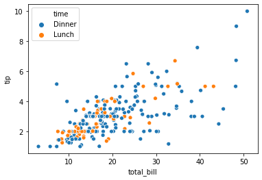

```python
import seaborn as sb
sb.scatterplot(x='total_bill', y='tip', hue='time', data=tips_table)
```

**Write a program to plot a pie chart of given ‘days’ data in ‘tips_table’ table.**

[output not shown]

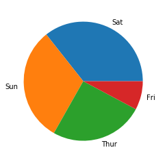

```python
sums = tips_table['day'].value_counts()
plt.pie(sums, labels=sums.index)
#show()
```

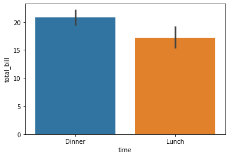

```python
sb.barplot(x='time', y='total_bill', data=tips_table)
```

**Plot the univariate distribution of various data in the ‘tips_table’ table with sb.distplot.**

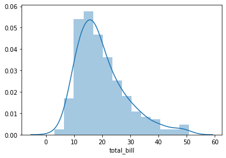

```python
sb.distplot(tips_table['total_bill'])
```

**Load a small flower dataset and display it using matplotlib grid function**

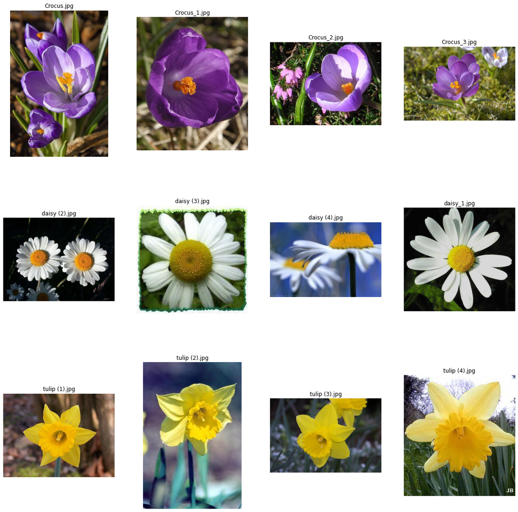

```python
import os
image_list = [(mpimg.imread(os.path.join('small_dataset/', img)), img) for img in os.listdir('small_dataset')]
plt.figure(figsize=(20, 20))
# print(image_list)
for i, img in enumerate(image_list):
    plt.subplot(3, 4, i + 1)
    plt.imshow(img[0])
    plt.title(img[1])
    plt.axis("off")
plt.show()
```